# Introduction / Business Problem

- This project is intended to use a geo-spatial analysis in the city of Chicago to cluster neighborhoods to make a decision on where to open a new coffee shop.
- A customer asks for a suggested location(s) near movie theater(s) and it is still underserved in a coffee retail segment.
- I will attempt to cluster Chicago neighborhoods for the proposed coffee shop locations with an added analysis of low crime rates, as the customer would like to stay away from the rough neighborhoods.

# Data Sources

- Foursquare API : https://developer.foursquare.com/ : find venues and locations
- Chicago Neighborhoods : https://data.cityofchicago.org/Facilities-Geographic-Boundaries/Boundaries-Neighborhoods/bbvz-uum9 - GeoJSON data
- Chicago Crime Data 2018 - https://data.cityofchicago.org/Public-Safety/Crimes-2018/3i3m-jwuy - exported into CSV
- 2010 Census Data Summarized to Chicago Community Areas - https://datahub.cmap.illinois.gov/dataset/2010-census-data-summarized-to-chicago-community-areas

# Methodology

- The 1st step will be to focus on areas with low crime rate per capita
  - We will work with both 'Chicago Crime Data' and 'Census Data', merge the 2 data sets to figure out what the crime rate per capita is in the Chicago community areas
    - There are 77 community areas in Chicago
  - Data cleaning will involve removing incomplete records, 'Domestic' reports, etc.
- The 2nd step will be focusing on 20 community areas with the least CrimeRate
  - We will use the Foursquare API to find Coffee Houses close to Movie Theaters within a walking distance
    - 1500 m sounds like a good 'walking distance' definition, we will use that.
- The final step will be k-Means Clustering, where we will analyze a resulting dataframe with prospective/recommended areas to open a new Coffee Shop

# Notebook

- Import the libraries

```python
import json
import pandas as pd
import numpy as np

import folium
from geopy.geocoders import Nominatim # convert an address into latitude and longitude values

import matplotlib.pyplot as plt
import matplotlib.cm as cm
import matplotlib.colors as colors
import seaborn as sns

import requests

from sklearn.cluster import KMeans
from sklearn.preprocessing import StandardScaler
```

- Read Chicago Crime data for 2018 : https://data.cityofchicago.org/Public-Safety/Crimes-2018/3i3m-jwuy - exported into CSV, as this is a big file.

```python
df = pd.read_csv('chicago-crime.csv')
```

```python
df.shape
```

```
(256383, 22)
```

```python
# let's discard some of the records we are not interested in:
df = df[df['Domestic'] == False]

# will also drop unnecessary columns:
columns_to_drop = [
    'ID',
    'Case Number',
    'Date',
    'Block',
    'Arrest',
    'Domestic',
    'Beat',
    'District',
    'Ward',
    'FBI Code',
    'Year',
    'Updated On',
    'Location']

df.drop(columns_to_drop, axis = 1, inplace=True)
```

```python
# we will drop all unknowns
df.dropna(inplace=True)

# convert into int64 for easier merges later on
df['CommunityNumber'] = df['Community Area'].astype(int)

# clean up data (0 in CommunityNumber)
df = df.loc[df['CommunityNumber'] != 0]

# sanity check
df.head()
```

|  | IUCR | Primary Type | Description | Location Description | Community Area | X Coordinate | Y Coordinate | Latitude | Longitude | CommunityNumber |
| --- | --- | --- | --- | --- | --- | --- | --- | --- | --- | --- |
| 0 | 0110 | HOMICIDE | FIRST DEGREE MURDER | STREET | 66.0 | 1162216.0 | 1860573.0 | 41.773071 | -87.680910 | 66 |
| 1 | 0110 | HOMICIDE | FIRST DEGREE MURDER | STREET | 66.0 | 1162216.0 | 1860573.0 | 41.773071 | -87.680910 | 66 |
| 2 | 0110 | HOMICIDE | FIRST DEGREE MURDER | PORCH | 23.0 | 1147479.0 | 1908100.0 | 41.903786 | -87.733717 | 23 |
| 4 | 0110 | HOMICIDE | FIRST DEGREE MURDER | STREET | 23.0 | 1150980.0 | 1902632.0 | 41.888713 | -87.721000 | 23 |
| 32 | 0810 | THEFT | OVER $500 | COMMERCIAL / BUSINESS OFFICE | 35.0 | 1177756.0 | 1882311.0 | 41.832385 | -87.623286 | 35 |

```python
# how big is the dataset now?
df.shape
```

```
(212584, 10)
```

```python
# we will count number of records per community area
crime_count = df.groupby('CommunityNumber').size().to_frame().reset_index()
crime_count = crime_count.rename(columns= {0: 'Count'})
```

- Will read "2010 Census Data Summarized to Chicago Community Areas", downloaded from https://datahub.cmap.illinois.gov/dataset/2010-census-data-summarized-to-chicago-community-areas
- This will give us an idea on community area population

```python
pop = pd.read_csv('chicago-population.csv')

# now clean the dataset
pop = pop.iloc[:,[0, 1, 2]]
pop.drop(pop.index[0], inplace=True)
pop.rename(columns={'GEOGNAME':'CommunityName', 'GEOGKEYX':'CommunityNumber', 'P0050001':'TotalPopulation'}, inplace=True)
pop.CommunityNumber = pd.to_numeric(pop.CommunityNumber, errors='coerce')
pop.TotalPopulation = pd.to_numeric(pop.TotalPopulation, errors='coerce')

# sanity check
pop.info()
```

```
<class 'pandas.core.frame.DataFrame'>
Int64Index: 77 entries, 1 to 77
Data columns (total 3 columns):
CommunityName      77 non-null object
CommunityNumber    77 non-null int64
TotalPopulation    77 non-null int64
dtypes: int64(2), object(1)
memory usage: 2.4+ KB
```

```python
# we will merge population counts and crime report summaries
df2 = pd.merge(crime_count, pop, on="CommunityNumber", how='left')

# calculate the elementary/rough crime rate (not scientific)
df2['CrimeRate'] = df2['Count'] / df2['TotalPopulation']

# and drop unnecessary columns - we already used them
# df2.drop(['Count', 'TotalPopulation'], axis = 1, inplace=True)  # drops column

# these communities we will focus on (20):
communities = df2.sort_values('CrimeRate').head(20)

print("We will focus on the following community areas with the lowest CrimeRate: \n" + str(communities.CommunityName.tolist()))
```

```
We will focus on the following community areas with the lowest CrimeRate:
['Edison Park', 'Forest Glen', 'Mount Greenwood', 'Norwood Park', 'Dunning', 'Clearing', 'Montclare', 'Jefferson Park', 'East Side', 'North Center', 'Beverly', 'Brighton Park', 'Albany Park', 'Bridgeport', 'Portage Park', 'West Ridge', 'Gage Park', 'Edgewater', 'West Lawn', 'Lincoln Square']
```

- Let's filter in only those records belonging to our list of communities:

```python
df = df[df.CommunityNumber.isin(communities.CommunityNumber.tolist())]
df.shape
```

```
(25443, 10)
```

- And will plot the neighborhoods:

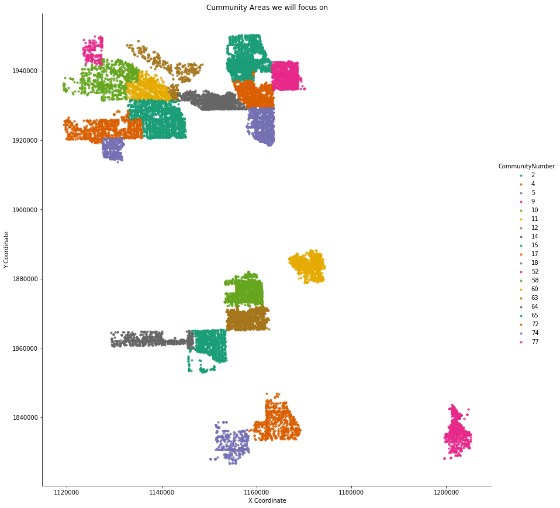

```python
sns.lmplot('X Coordinate',
           'Y Coordinate',
           data=df[:],
           fit_reg=False,
           hue="CommunityNumber",
           palette='Dark2',
           height=12,
           ci=2,
           scatter_kws={"marker": "D",
                        "s": 10})
ax = plt.gca()
ax.set_title("Cummunity Areas we will focus on");
```

- We will need to get Lang/Lat for the communities:

```python
def pupulate_long_lat(x):
    address = x['CommunityName'] + ", Chicago, IL"
    location = geolocator.geocode(address)
    x['Latitude'] = location.latitude
    x['Longitude'] = location.longitude
    return x
```

```python
geolocator = Nominatim(user_agent="my-coursera-app")
communities = communities.apply(pupulate_long_lat,axis=1)
```

```python
communities.head()
```

|  | CommunityNumber | Count | CommunityName | TotalPopulation | CrimeRate | Latitude | Longitude |
| --- | --- | --- | --- | --- | --- | --- | --- |
| 8 | 9 | 204 | Edison Park | 11187 | 0.018235 | 42.005733 | -87.814004 |
| 11 | 12 | 415 | Forest Glen | 18508 | 0.022423 | 41.991752 | -87.751673 |
| 73 | 74 | 459 | Mount Greenwood | 19093 | 0.024040 | 41.698089 | -87.708662 |
| 9 | 10 | 998 | Norwood Park | 37023 | 0.026956 | 41.985590 | -87.800575 |
| 16 | 17 | 1135 | Dunning | 41932 | 0.027068 | 41.952809 | -87.796449 |

## We will now use the Foursquare API for each community area to get the list of existing Coffee Shops

```python
CLIENT_ID = '...' # your Foursquare ID
CLIENT_SECRET = '...' # your Foursquare Secret
VERSION = '20180605' # Foursquare API version
```

```python
# common functions:
def get_category_type(row):
    try:
        categories_list = row['categories']
    except:
        categories_list = row['venue.categories']

    if len(categories_list) == 0:
        return None
    else:
        return categories_list[0]['name']

def getNearbyVenues(categoryID, names, latitudes, longitudes, radius):
    venues_list = []
    for name, lat, lng in zip(names, latitudes, longitudes):
        # create the API request URL
        url = 'https://api.foursquare.com/v2/venues/explore?&client_id={}&client_secret={}&v={}&ll={},{}&radius={}&limit={}&categoryId={}'.format(
            CLIENT_ID,
            CLIENT_SECRET,
            VERSION,
            lat,
            lng,
            radius,
            LIMIT,
            categoryID)
        #print(requests.get(url).json())
        try:
            # make the GET request
            results = requests.get(url).json()["response"]['groups'][0]['items']
        except:
            print('Your quota may have been exceeded')
            return

        # return only relevant information for each nearby venue
        venues_list.append([(
            name,
            lat,
            lng,
            v['venue']['name'],
            v['venue']['location']['lat'],
            v['venue']['location']['lng'],
            v['venue']['categories'][0]['name']) for v in results])

    nearby_venues = pd.DataFrame([item for venue_list in venues_list for item in venue_list])
    nearby_venues.columns = ['CommunityName',
                  'CommunityNameLatitude',
                  'CommunityNameLongitude',
                  'Venue',
                  'VenueLatitude',
                  'VenueLongitude',
                  'VenueCategory']

    return(nearby_venues)
```

- Foursquare calls to get 2 lists
  - Coffee Shops
  - Movie Theaters

```python
LIMIT = 100
radius = 1500 # 1 km is a good enough redius = walking distance

# categories : see https://developer.foursquare.com/docs/resources/categories
# coffee shops
categoryID = '4bf58dd8d48988d1e0931735'
chicago_coffee_shops = getNearbyVenues(categoryID=categoryID,names=communities['CommunityName'],latitudes=communities['Latitude'],longitudes=communities['Longitude'],radius=radius)
# movie theaters
categoryID = '4bf58dd8d48988d17f941735'
chicago_movie_theaters = getNearbyVenues(categoryID=categoryID,names=communities['CommunityName'],latitudes=communities['Latitude'],longitudes=communities['Longitude'],radius=radius)
```

```python
chicago_coffee_shops.shape
```

```
(156, 7)
```

```python
chicago_movie_theaters.shape
```

```
(35, 7)
```

```python
chicago_coffee_shops["VenueCategory"].value_counts()
```

```
Coffee Shop    92
Café           60
Tea Room        4
Name: VenueCategory, dtype: int64
```

```python
chicago_movie_theaters["VenueCategory"].value_counts()
```

```
Movie Theater          21
Indie Movie Theater     8
Multiplex               5
Pub                     1
Name: VenueCategory, dtype: int64
```

## Map of Venues

```python
geolocator = Nominatim(user_agent="my-coursera-app")
address = "Chicago, IL"
location = geolocator.geocode(address)

m = folium.Map(location=[location.latitude, location.longitude], zoom_start=11)

# add markers to map
# blue = coffee shops
# red = movie theaters

for lat, lng, venue in zip(chicago_coffee_shops['VenueLatitude'], chicago_coffee_shops['VenueLongitude'], chicago_coffee_shops['Venue']):
    label = '{}'.format(venue)
    label = folium.Popup(label, parse_html=True)
    folium.CircleMarker(
        [lat, lng],
        radius=5,
        popup=label,
        color='blue',
        fill=True,
        fill_color='#3186cc',
        fill_opacity=0.7).add_to(m)

for lat, lng, venue in zip(chicago_movie_theaters['VenueLatitude'], chicago_movie_theaters['VenueLongitude'], chicago_movie_theaters['Venue']):
    label = '{}'.format(venue)
    label = folium.Popup(label, parse_html=True)
    folium.CircleMarker(
        [lat, lng],
        radius=5,
        popup=label,
        color='red',
        fill=True,
        fill_color='#3186cc',
        fill_opacity=0.7).add_to(m)

m
```

[interactive chart not shown]

- Will narrow down the list, will call it 'candidate_list'

```python
candidate_areas = communities[communities.CommunityName.isin(chicago_movie_theaters.CommunityName.tolist())]
```

```python
chicago_coffee_shops_count = chicago_coffee_shops[chicago_coffee_shops.CommunityName.isin(candidate_areas.CommunityName.tolist())]
chicago_coffee_shops_count.shape
```

```
(131, 7)
```

- Count Coffee Shops per community area:

```python
chicago_coffee_shops_count = chicago_coffee_shops_count['CommunityName'].value_counts().reset_index()
chicago_coffee_shops_count.rename(columns={'CommunityName':'Venues','index':'CommunityName'}, inplace=True)
```

```python
chicago_coffee_shops_count
```

|  | CommunityName | Venues |
| --- | --- | --- |
| 0 | Lincoln Square | 23 |
| 1 | Edgewater | 21 |
| 2 | North Center | 20 |
| 3 | Albany Park | 16 |
| 4 | Bridgeport | 11 |
| 5 | Portage Park | 9 |
| 6 | Edison Park | 7 |
| 7 | Jefferson Park | 6 |
| 8 | Gage Park | 5 |
| 9 | Dunning | 5 |
| 10 | West Ridge | 4 |
| 11 | Brighton Park | 2 |
| 12 | East Side | 1 |
| 13 | West Lawn | 1 |

```python
candidate_areas = pd.merge(candidate_areas, chicago_coffee_shops_count, on="CommunityName", how='left')
candidate_areas['VenuesPerCapita'] = candidate_areas['Venues']/candidate_areas['TotalPopulation']
```

## Analyze This!

```python
X_train = candidate_areas[['TotalPopulation', 'Venues']].copy()
scaler = StandardScaler()
X_train[['TotalPopulation', 'Venues']] = scaler.fit_transform(X_train[['TotalPopulation', 'Venues']])
X_train.head()
```

|  | TotalPopulation | Venues |
| --- | --- | --- |
| 0 | -1.846208 | -0.320087 |
| 1 | 0.086931 | -0.591676 |
| 2 | -0.949525 | -0.455881 |
| 3 | -1.100806 | -1.134853 |
| 4 | -0.545921 | 1.445240 |

```
Text(0,0.5,'Venues')
```

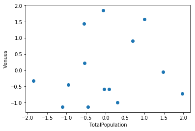

```python
fig = plt.figure()
ax = fig.add_subplot(111)

plt.scatter(X_train['TotalPopulation'], X_train['Venues'])
ax.set_xlabel('TotalPopulation')
ax.set_ylabel('Venues')
```

## Pearson Correlation

- The results are not too convincing, but we will still continue

```python
X_train.corr()
```

|  | TotalPopulation | Venues |
| --- | --- | --- |
| TotalPopulation | 1.000000 | 0.151986 |
| Venues | 0.151986 | 1.000000 |

## Clustering

- First step is to determine how many clusters we should divide the neighbourhoods into.
- Will use the Elbow method
- We'll loop through and get the scores

```python
num_clusters = range(1, 14)
kmeans = [KMeans(n_clusters=i) for i in num_clusters]
score = [kmeans[i].fit(X_train).score(X_train) for i in range(len(kmeans))]
```

- We will plot the score vs the number of clusters and look for the "elbow" where you get diminishing returns

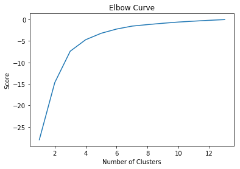

```python
plt.plot(num_clusters, score)
plt.xlabel('Number of Clusters')
plt.ylabel('Score')
plt.title('Elbow Curve')
plt.show()
```

- Looks like it is 4

```python
# set number of clusters
kclusters = 4

# run k-means clustering
kmeans = KMeans(n_clusters=kclusters, random_state=0).fit(X_train)

# check cluster labels generated for each row in the dataframe
kmeans.labels_[0:14]
```

```
array([1, 3, 1, 1, 0, 3, 0, 1, 2, 2, 3, 0, 3, 0], dtype=int32)
```

```python
# add clustering labels back to our original data set
candidate_areas['ClusterLabels'] = kmeans.labels_
candidate_areas.head()
```

|  | CommunityNumber | Count | CommunityName | TotalPopulation | CrimeRate | Latitude | Longitude | Venues | VenuesPerCapita | ClusterLabels |
| --- | --- | --- | --- | --- | --- | --- | --- | --- | --- | --- |
| 0 | 9 | 204 | Edison Park | 11187 | 0.018235 | 42.005733 | -87.814004 | 7 | 0.000626 | 1 |
| 1 | 17 | 1135 | Dunning | 41932 | 0.027068 | 41.952809 | -87.796449 | 5 | 0.000119 | 3 |
| 2 | 11 | 894 | Jefferson Park | 25448 | 0.035130 | 41.969738 | -87.763118 | 6 | 0.000236 | 1 |
| 3 | 52 | 815 | East Side | 23042 | 0.035370 | 41.694618 | -87.533387 | 1 | 0.000043 | 1 |
| 4 | 5 | 1155 | North Center | 31867 | 0.036244 | 41.956107 | -87.679160 | 20 | 0.000628 | 0 |

## Clusters Map

```python
# clusters map
map_c = folium.Map(location=[location.latitude, location.longitude], zoom_start=11)

# set color scheme for the clusters
x = np.arange(kclusters)
ys = [i+x+(i*x)**2 for i in range(kclusters)]
colors_array = cm.rainbow(np.linspace(0, 1, len(ys)))
rainbow = [colors.rgb2hex(i) for i in colors_array]

# add markers to the map
markers_colors = []

for lat, lng, community, cluster in zip(candidate_areas['Latitude'], candidate_areas['Longitude'], candidate_areas['CommunityName'], candidate_areas['ClusterLabels']):
    label = '{} Cluster {}'.format(community, cluster)
    label = folium.Popup(label, parse_html=True)
    folium.CircleMarker(
        [lat, lng],
        radius=5,
        popup=label,
        color=rainbow[cluster-1],
        fill=True,
        fill_color=rainbow[cluster-1],
        fill_opacity=0.7).add_to(map_c)

map_c
```

[interactive chart not shown]

- Let's plot the clusters for Venues/TotalPopulaiton

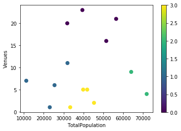

```python
fig = plt.figure()
ax = fig.add_subplot(111)

cluster = candidate_areas['ClusterLabels'].tolist()
x = candidate_areas['TotalPopulation'].tolist()
y = candidate_areas['Venues'].tolist()

scatter = ax.scatter(x,y,c=cluster,s=50)
ax.set_xlabel('TotalPopulation')
ax.set_ylabel('Venues')
plt.colorbar(scatter)
```

# Results

- Based on this analysis we should recommend our customer to focus foremost on Cluster 3 :
  - It is underserved in terms of Coffee Houses per capita (with a requirement on the neighboring Movie Theater)

```python
# here is the list:
candidate_areas.loc[candidate_areas['ClusterLabels'] == 3]['CommunityName']
```

```
1           Dunning
5     Brighton Park
10        Gage Park
12        West Lawn
Name: CommunityName, dtype: object
```

# Discussion

- I would like to mention that I was not too happy to see such a low Pearson Correlation, so the next iteration of the model should pick different criteria.